# Creating images with R

with a little bit of magick

Ethan Sio

```css
body {
  background-color: #7B6D8D;
  color: #EC9688;
  font-family: "Park Avenue";
}

h1 {
  background-color: #000000;
  padding: 2px;
}

pre {
  background-color:#EC9688;
}
```

## Project requirements

During the Part A it allowed to me practice what I had learnt in the lectures when learning markdown, which really allowed me to consolidate my knowledge on it. In my README.md files I completed all the requirements for the task.I used 2 different levels of headers header 1 being “Stats 220” and header 2 being all the other sub headers. I used the ordered list to list down the current projects done in stats 220 and also list my favorite papers this semester in order, as just a general idea of me.I then used the unordered list to say just plain simple facts about me as this will be my repo for stats 220.I then used bolding to emphasize the parts that I think are important but used both bold and italics on “More to come later on in the semester” to further emphasize the importance in it. I then linked my linkedin page, just for i guess more connections and also more info about me.

[Github Repo](https://github.com/AsianHard123/stats220)

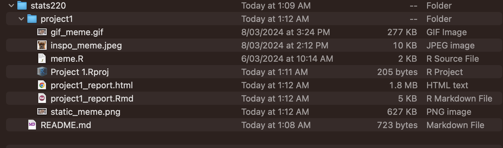

Files

## My meme

[figure not shown]

For my inspo meme the key components that I took from the image is the animal with attitude, and also the text which is like a point of view of what the animal will be thinking towards its owners. The main things I changed was I used a differnt animal that had differnte expressions allowing me to keep the core of this meme but changing it up a bit.

[figure not shown]

```r
library(magick)
#static image meme
meme_text <- image_blank(width = 500, height = 50, color = "#000000") %>% #Creating Block for text
  image_annotate(text = "When my owner walks past without giving me a cuddle", color = "#FFFFFF", size = 20, gravity = "center")
meme_image <- image_read("https://i.kym-cdn.com/entries/icons/original/000/048/010/side_eye_cat.jpg") %>% #Scailing image to fit block of text
  image_scale(500)

#Producing the static meme
meme_vector <- c(meme_text, meme_image)
meme <- image_append(meme_vector, stack = TRUE) #Combining image and block of text
meme
```

```r
image_write(meme, "static_meme.png") #Saving meme as a png file
```

[figure not shown]

gif

```r
#gif meme code

#Creating frames for the gif
frame1 <- meme
frame2 <- image_read("https://media.tenor.com/a467V24M0IUAAAAe/cat-bombastic-side-eye.png") %>%
  image_scale(500) %>%
  image_resize("500x500") #resizing so that all frames are the same
frame3 <- image_read("https://assets.coingecko.com/coins/images/34354/large/photo_2024-01-07_21.44.19.jpeg?1704703981") %>%
  image_scale(500) %>%
  image_resize("500x500") #resizing so that all frames are the same
frame4 <- image_read("https://i.redd.it/si6diz4wjqqb1.jpg") %>%
  image_scale(500) %>%
  image_resize("500x500") #resizing so that all frames are the same

#Appending the block of code to each frame
frame2_wtxt <- image_append(c(meme_text, frame2), stack = TRUE)
frame3_wtxt <- image_append(c(meme_text, frame3), stack = TRUE)
frame4_wtxt <- image_append(c(meme_text, frame4), stack = TRUE)

#Producing the gif
frames <- c(frame1, frame2_wtxt, frame3_wtxt, frame4_wtxt)
gif <- image_animate(frames, fps = 1)
gif

image_write(gif, "gif_meme.gif") #Saving meme as a gif
```

## Creativity

So what I did for this project, is that I used the same idea of the meme being about what the possible thoughts of a animal towards their owner could be in a certain situation. So the perfect thing for this for me is a side-eye cat. They side-eye basically portrays the like attitude the cat is showing to its owner all most like it being sassy. I think the creativity is shown through my use of more current type humour has the “side-eye” is a rather popular thing via tiktok.I also decided to do for a cat, as I would say genreally cats are usually portrayed more evil then dogs. But with this idea that cat are portrayed as more evil then dogs I used the caption to show that cats are also cute and also deserve love and arnt allways as portrayed.

## Learning reflection

One of the most important ideas that I learned during module 1 is the process on making a gif using R, by producing each frame separately using a image/text for them, then combing them into one and using image_animate to produce a gif out of these combined frames.By learning more R I am now curious to find out how far R code can go and how much that R code is able to do once you are very proficient and efficient with all there is to do with R.